# UD2 N04

# Análisis exploratorio de datos climáticos

Realizamos un estudio gráfico de la evolución de la temperatura global desde 1850. Queremos saber:

- Si ha habido un aumento significativo de la misma.
- Si se producen más anomalías que antes térmicamente.
- Sacar ideas y descriptores a partir de la información proporcionada.

Los datos son de las temperaturas globales y están descritos como:

Global Land and Ocean-and-Land Temperatures (GlobalTemperatures.csv):

- Date: starts in 1750 for average land temperature and 1850 for max and min land temperatures and global ocean and land temperatures
- LandAverageTemperature: global average land temperature in celsius
- LandAverageTemperatureUncertainty: the 95% confidence interval around the average
- LandMaxTemperature: global average maximum land temperature in celsius
- LandMaxTemperatureUncertainty: the 95% confidence interval around the maximum land temperature
- LandMinTemperature: global average minimum land temperature in celsius
- LandMinTemperatureUncertainty: the 95% confidence interval around the minimum land temperature
- LandAndOceanAverageTemperature: global average land and ocean temperature in celsius
- LandAndOceanAverageTemperatureUncertainty: the 95% confidence interval around the global average land and ocean temperature

Al haber muchos datos que se empiezan a recoger a partir de 1850, la exploración se hará desde esa fecha.

```r
df <- read.csv("UD2_N04_GlobalTemperatures.csv")
head(df)
```

```
##           dt LandAverageTemperature LandAverageTemperatureUncertainty
## 1 1750-01-01                  3.034                             3.574
## 2 1750-02-01                  3.083                             3.702
## 3 1750-03-01                  5.626                             3.076
## 4 1750-04-01                  8.490                             2.451
## 5 1750-05-01                 11.573                             2.072
## 6 1750-06-01                 12.937                             1.724
##   LandMaxTemperature LandMaxTemperatureUncertainty LandMinTemperature
## 1                 NA                            NA                 NA
## 2                 NA                            NA                 NA
## 3                 NA                            NA                 NA
## 4                 NA                            NA                 NA
## 5                 NA                            NA                 NA
## 6                 NA                            NA                 NA
##   LandMinTemperatureUncertainty LandAndOceanAverageTemperature
## 1                            NA                             NA
## 2                            NA                             NA
## 3                            NA                             NA
## 4                            NA                             NA
## 5                            NA                             NA
## 6                            NA                             NA
##   LandAndOceanAverageTemperatureUncertainty
## 1                                        NA
## 2                                        NA
## 3                                        NA
## 4                                        NA
## 5                                        NA
## 6                                        NA
```

```r
str(df)
```

```
## 'data.frame':    3192 obs. of  9 variables:
##  $ dt                                       : Factor w/ 3192 levels "1750-01-01","1750-02-01",..: 1 2 3 4 5 6 7 8 9 10 ...
##  $ LandAverageTemperature                   : num  3.03 3.08 5.63 8.49 11.57 ...
##  $ LandAverageTemperatureUncertainty        : num  3.57 3.7 3.08 2.45 2.07 ...
##  $ LandMaxTemperature                       : num  NA NA NA NA NA NA NA NA NA NA ...
##  $ LandMaxTemperatureUncertainty            : num  NA NA NA NA NA NA NA NA NA NA ...
##  $ LandMinTemperature                       : num  NA NA NA NA NA NA NA NA NA NA ...
##  $ LandMinTemperatureUncertainty            : num  NA NA NA NA NA NA NA NA NA NA ...
##  $ LandAndOceanAverageTemperature           : num  NA NA NA NA NA NA NA NA NA NA ...
##  $ LandAndOceanAverageTemperatureUncertainty: num  NA NA NA NA NA NA NA NA NA NA ...
```

Procesamos los datos seleccionando las fechas desde 1850, que no tienen valores faltantes.

```r
# eliminamos los valores faltantes
df <- na.omit(df)

# damos formato de fecha a la columna dt (Date)
df$dt <- as.Date(df$dt,"%Y-%m-%d")

# creamos una columna con información de mes y otra con información de año
df$Month<-as.numeric(format(df$dt,"%m"))
df$Month.String<-format(df$dt,"%B")
df$Year<-as.numeric(format(df$dt,"%Y"))

head(df, 20)
```

```
##              dt LandAverageTemperature LandAverageTemperatureUncertainty
## 1201 1850-01-01                  0.749                             1.105
## 1202 1850-02-01                  3.071                             1.275
## 1203 1850-03-01                  4.954                             0.955
## 1204 1850-04-01                  7.217                             0.665
## 1205 1850-05-01                 10.004                             0.617
## 1206 1850-06-01                 13.150                             0.614
## 1207 1850-07-01                 14.492                             0.614
## 1208 1850-08-01                 14.039                             0.802
## 1209 1850-09-01                 11.505                             0.675
## 1210 1850-10-01                  8.091                             0.863
## 1211 1850-11-01                  4.733                             1.149
## 1212 1850-12-01                  2.803                             1.183
## 1213 1851-01-01                  2.431                             1.122
## 1214 1851-02-01                  2.508                             1.100
```

[output cut: 69 more lines]

```r
str(df)
```

```
## 'data.frame':    1992 obs. of  12 variables:
##  $ dt                                       : Date, format: "1850-01-01" "1850-02-01" ...
##  $ LandAverageTemperature                   : num  0.749 3.071 4.954 7.217 10.004 ...
##  $ LandAverageTemperatureUncertainty        : num  1.105 1.275 0.955 0.665 0.617 ...
##  $ LandMaxTemperature                       : num  8.24 9.97 10.35 12.93 15.65 ...
##  $ LandMaxTemperatureUncertainty            : num  1.74 3.01 2.4 1 2.41 ...
##  $ LandMinTemperature                       : num  -3.21 -2.29 -1.9 1.02 3.81 ...
##  $ LandMinTemperatureUncertainty            : num  2.82 1.62 1.41 1.33 1.35 ...
##  $ LandAndOceanAverageTemperature           : num  12.8 13.6 14 14.7 15.5 ...
##  $ LandAndOceanAverageTemperatureUncertainty: num  0.367 0.414 0.341 0.267 0.249 0.245 0.238 0.28 0.254 0.297 ...
##  $ Month                                    : num  1 2 3 4 5 6 7 8 9 10 ...
##  $ Month.String                             : chr  "January" "February" "March" "April" ...
##  $ Year                                     : num  1850 1850 1850 1850 1850 1850 1850 1850 1850 1850 ...
##  - attr(*, "na.action")=Class 'omit'  Named int [1:1200] 1 2 3 4 5 6 7 8 9 10 ...
##   .. ..- attr(*, "names")= chr [1:1200] "1" "2" "3" "4" ...
```

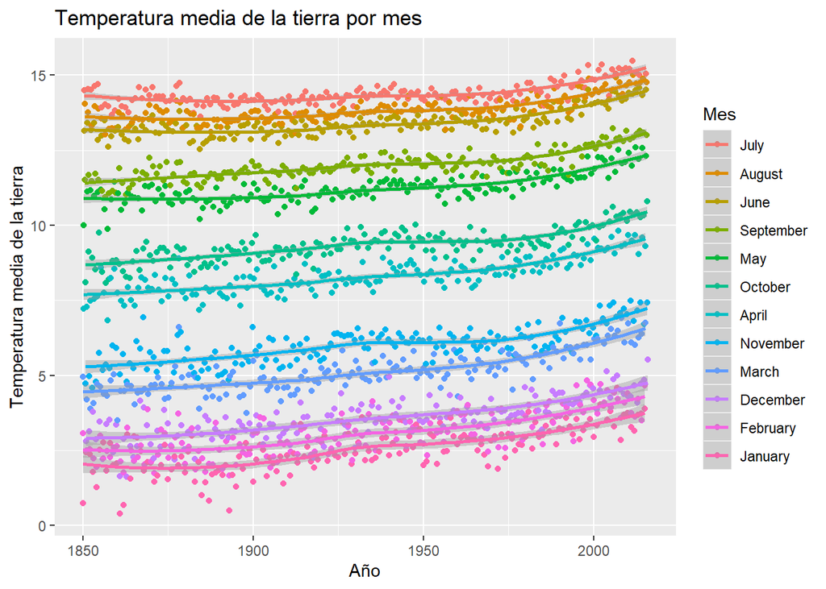

```r
library(ggplot2)
library(dplyr)
#tierra
ggplot(df,aes(x=dt,y=LandAverageTemperature,colour=reorder(Month.String,-LandAverageTemperature,mean)))+
  geom_point()+
  geom_smooth(method="loess")+
  labs(title="Temperatura media de la tierra por mes",
       x="Año",
       y="Temperatura media de la tierra",
       colour="Mes")
```

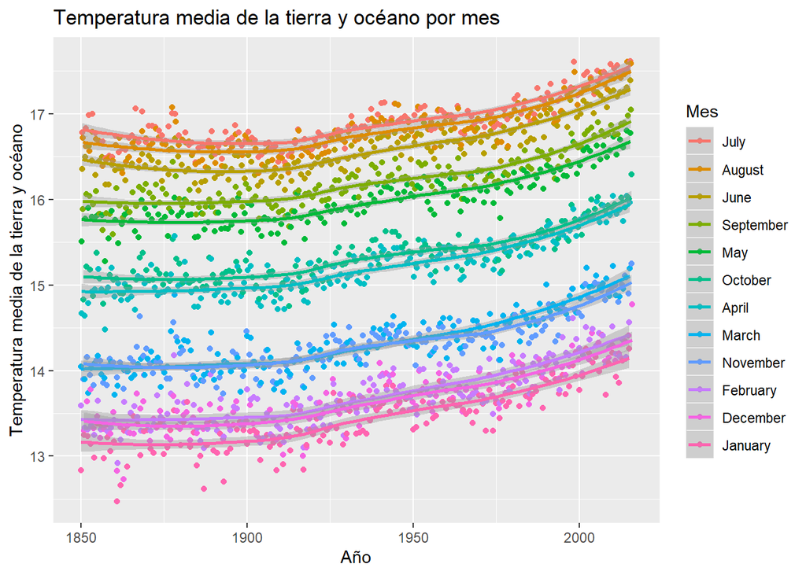

```r
#tierra y océano
ggplot(df,aes(x=dt,y=LandAndOceanAverageTemperature,colour=reorder(Month.String,-LandAndOceanAverageTemperature,mean)))+
  geom_point()+
  geom_smooth(method="loess")+
  labs(title="Temperatura media de la tierra y océano por mes",
       x="Año",
       y="Temperatura media de la tierra y océano",
       colour="Mes")
```

Representamos la temperatura máxima menos la mínima en este intervalo de tiempo para la tierra. No se aprecia una diferencia ó evolución en la diferencia de temperatura máxima y mínima creciente por año. Si lo hacemos por cuatrimestre tampoco se observa una evolución en ninguna de las estaciones.

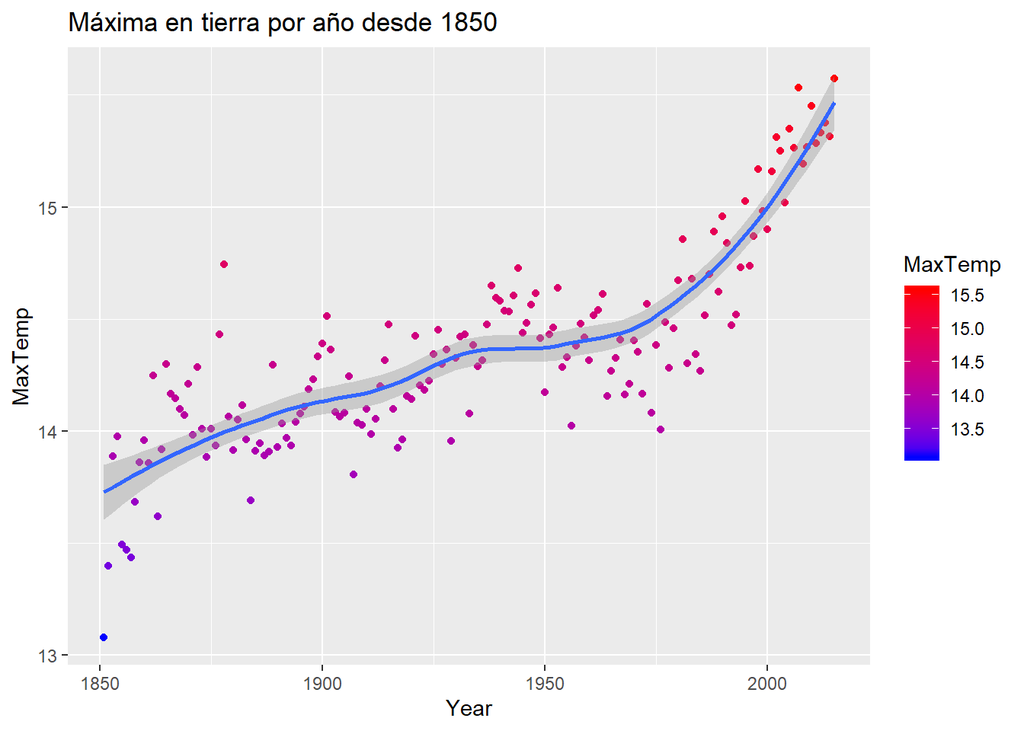

```r
df$MaxMinLandDifference <- df$LandMaxTemperature - df$LandMinTemperature
df$Quarter <- quarters(df$dt)

#gráfica de las máximas por año
df %>%
  filter(Year>1850) %>%
  group_by(Year) %>%
  summarise(MaxTemp = mean(LandMaxTemperature)) -> MaxByYear

df %>%
  filter(Year>1850) %>%
  group_by(Year) %>%
  summarise(MinTemp = mean(LandMinTemperature)) -> MinByYear

qplot(Year, MaxTemp, data=MaxByYear, main="Máxima en tierra por año desde 1850",geom=c("point","smooth"))+ aes(colour = MaxTemp) + scale_color_gradient(low="blue", high="red")
```

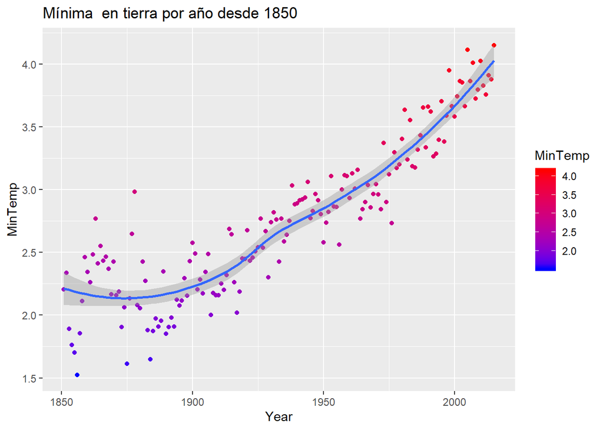

```r
qplot(Year, MinTemp, data=MinByYear, main="Mínima  en tierra por año desde 1850",geom=c("point","smooth"))+ aes(colour = MinTemp) + scale_color_gradient(low="blue", high="red")
```

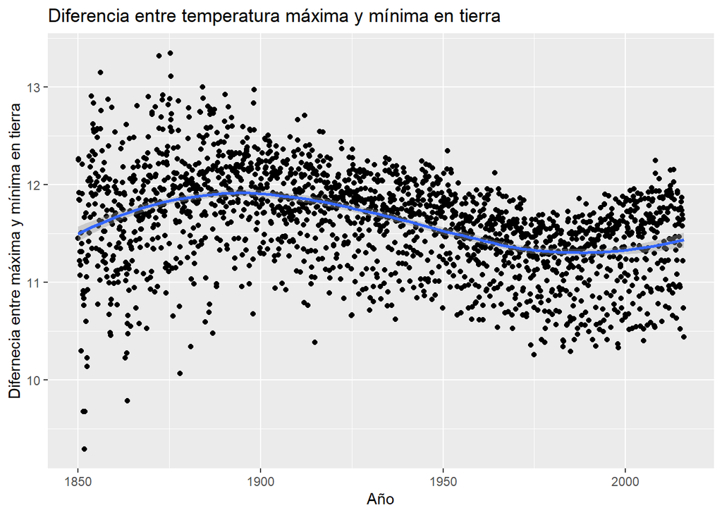

```r
#gráfica por año
ggplot(df,aes(x=dt,y=MaxMinLandDifference))+
  geom_point()+
  geom_smooth(method="loess")+
  labs(title="Diferencia entre temperatura máxima y mínima en tierra",
       x="Año",
       y="Difernecia entre máxima y mínima en tierra")
```

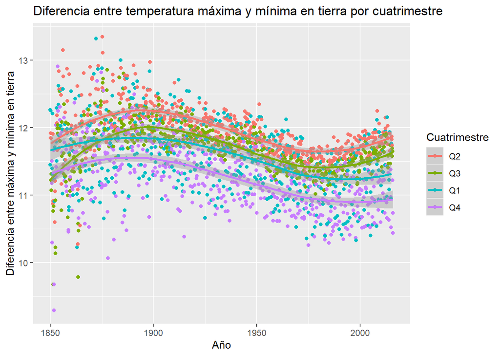

```r
#gráfica con la evolución cuatrimestral
ggplot(df,aes(x=dt,y=MaxMinLandDifference,colour=reorder(Quarter,-MaxMinLandDifference,mean)))+
  geom_point()+
  geom_smooth(method="loess")+
  labs(title="Diferencia entre temperatura máxima y mínima en tierra por cuatrimestre",
       x="Año",
       y="Diferencia entre máxima y mínima en tierra",
       colour="Cuatrimestre")
```

Evolución de la incertidumbre sobre la temperatura. Se ve que las medidas han evolucionado mucho.

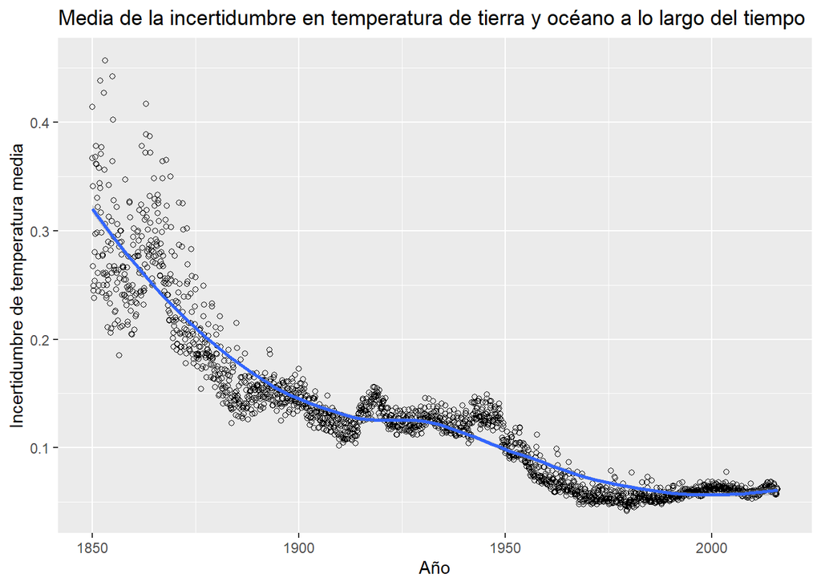

```r
ggplot(df,aes(x=dt,y=LandAndOceanAverageTemperatureUncertainty))+
  geom_point(shape=1)+
  geom_smooth(method="loess")+
  labs(title="Media de la incertidumbre en temperatura de tierra y océano a lo largo del tiempo",
       x="Año",
       y="Incertidumbre de temperatura media")
```

Vemos la distribución de la temperatura de tierra y océano a lo largo del año. Casi todos los meses tienen las mismas anomalías ó valores atípicos hacia arriba y hacia abajo.

```r
df %>% group_by(Month) %>%
  summarise(AverageTemp = mean(LandAndOceanAverageTemperature)) -> MonthTemp

MonthTemp
```

```
## # A tibble: 12 x 2
##    Month AverageTemp
##    <dbl>       <dbl>
##  1     1        13.5
##  2     2        13.7
##  3     3        14.3
##  4     4        15.2
##  5     5        16.0
##  6     6        16.6
##  7     7        16.9
##  8     8        16.8
##  9     9        16.2
## 10    10        15.3
## 11    11        14.3
## 12    12        13.7
```

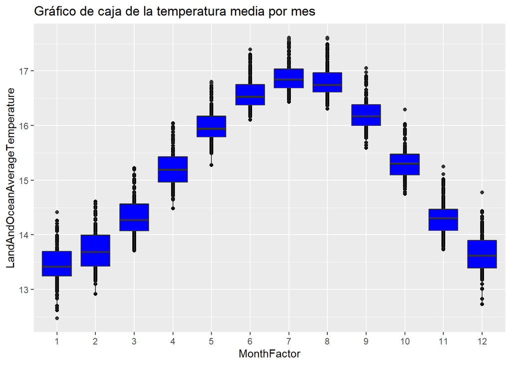

```r
df$MonthFactor <- as.factor(df$Month)

qplot(x =  MonthFactor, y = LandAndOceanAverageTemperature, data = df) +
  ggtitle("Gráfico de caja de la temperatura media por mes")+geom_boxplot(fill="blue1")
```

Temperaturas medias según mes en años señalados

```r
df_sel <- subset(df,Year %in% c(1850,1900,1950,1975,1995,2004))
head(df_sel)
```

```
##              dt LandAverageTemperature LandAverageTemperatureUncertainty
## 1201 1850-01-01                  0.749                             1.105
## 1202 1850-02-01                  3.071                             1.275
## 1203 1850-03-01                  4.954                             0.955
## 1204 1850-04-01                  7.217                             0.665
## 1205 1850-05-01                 10.004                             0.617
## 1206 1850-06-01                 13.150                             0.614
##      LandMaxTemperature LandMaxTemperatureUncertainty LandMinTemperature
## 1201              8.242                         1.738             -3.206
## 1202              9.970                         3.007             -2.291
## 1203             10.347                         2.401             -1.905
## 1204             12.934                         1.004              1.018
## 1205             15.655                         2.406              3.811
## 1206             18.946                         2.817              7.106
##      LandMinTemperatureUncertainty LandAndOceanAverageTemperature
```

[output cut: 20 more lines]

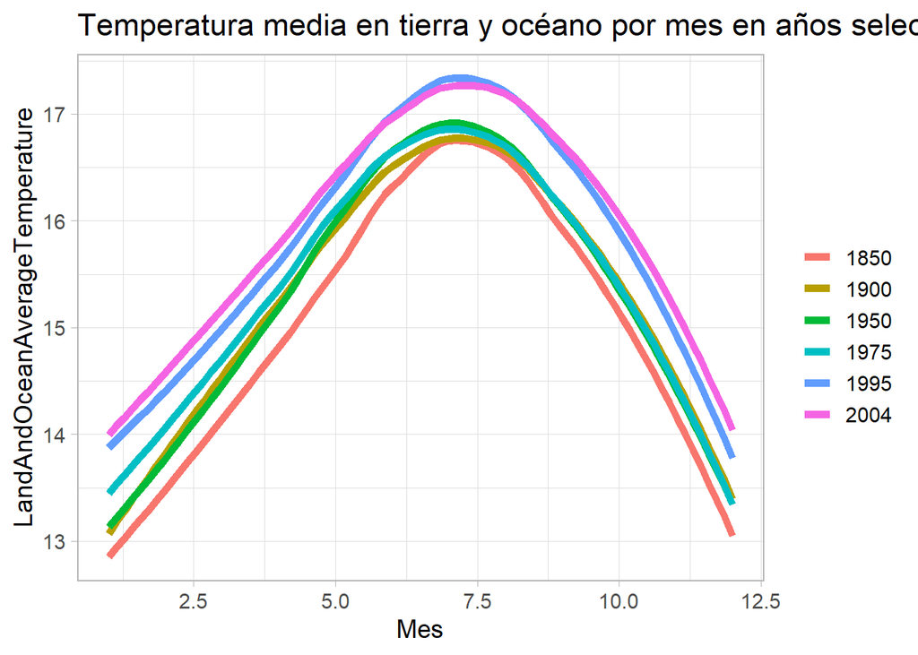

```r
ggplot(df_sel, aes(x=(Month), y=LandAndOceanAverageTemperature, color=as.factor(Year))) +
  geom_smooth(se=FALSE,fill=NA, size=2) +
  theme_light(base_size=14) +
  xlab("Mes")+
  ylab("LandAndOceanAverageTemperature") +
  scale_color_discrete("") +
  ggtitle("Temperatura media en tierra y océano por mes en años seleccionados")
```